# Employment Opportunities Predictor, Place-level

Author

JP Walsh and Aaron R. Williams

Published

February 25, 2025

*Program for the creation of the Employment Opportunities Upward Mobility Predictor at the place-level*

ACS Code: Initially written by Tina Chelidze, updated by JP Walsh and Aaron Williams 2022-2023 and again by JP Walsh (2024-2025).

Primary data derived from the IPUMS API. Based on processes developed by Paul Johnson and Kevin Werner in SAS.

*User note* This program depends on extracts from the IPUMS ACS API interface. If you are updating the extract please remember to update the extract_date to reflect the time of the latest extract in the Housekeeping section of this program.

Please select your year by updating ‘params$year’ in the YAML parameters above.

*Internal users* If you are an internal tester using the AWS feature of this program remember to enter the passkey into your environment using Sys.setenv(). Authentication steps are nicely explained in this [blog](https://www.gormanalysis.com/blog/connecting-to-aws-s3-with-r/). You will have to request access to the access key.

*User warning* The ACS micro data used to create this metric is large and will take time to read in. It is strongly recommended that you use a server with significant computing power to run this. For internal Urban Institute users, the SAS server provides a good option.

## Housekeeping

Read in packages for use. If you do not have an IPUMS API key you will need to make one via the [IPUMS website](https://www.ipums.org/).

```r
library(tidyverse)
library(ipumsr)
library(reactable)
library(srvyr)
library(scales)
library(furrr)
library(tictoc)

options(scipen = 999)

theme_set(theme_minimal())

# DO NOT PUSH YOUR API KEY. You only have to run this once and then comment it out as below.
#set_ipums_api_key("Your KEY", save = TRUE)

s3_dir <- "metric_name/data/acs"
my_bucket <- "mobility-from-poverty-test"

source(here::here("functions", "API", "extract_ipums_aws.R"))
source(here::here("functions", "API", "ipums_repwt_employment_aws.R"))
source(here::here("functions", "testing", "evaluate_final_data.R"))
source(here::here("09_employment", "R", "finalize_metric.R"))
source(here::here("09_employment", "R", "calc_survey_mean.R"))
source(here::here("09_employment", "R", "calc_survey_mean_subgroup.R"))
```

Date of IPUMS extract. Denote the latest date that the IPUMS extract was changed and pulled both for the overall data and the repweights. The recommended date notation format is “mm_dd_yy”.

For internal reviewers, if you plan to utilize AWS keep this date as it was last entered by the metric lead unless you intend to change the extract.

```r
ipums_extract_date <- "01_13_25"
ipums_repwt_extract_date <- "01_13_25"
```

If this is to update a single year of new data please set single_year_update to “Yes”. If not, set it to “No”.

```r
single_year_update = "No"
```

Define existing intermediate years and read them into function to combine.

```r
existing_years <- c("2014", "2015", "2016", "2017", "2018", "2019", "2021", "2022", "2023")
```

## Read ACS Data

Read in the ACS extracts using the `extract_ipums()` function. Make sure to change the survey list to reflect what years you want to include in the data. The surveys being used in the code are defined in the code chunk below. For a list of available ACS surveys and their titles via the IPUMSR package you can run the following function: get_sample_info(“acs”).

```r
acs_surveys <- list(paste0("us", params$year, "a"))
```

### Person-Level Data

Run extract. This will trigger an import process through IPUMS. It is encouraged to add detail to your extract description so it is clear what the extract was used for.

Date of latest extract noted above. If a new IPUMS pull is required the extract_date argument below must be updated to track that new data was downloaded. The extract only needs to be updated if changes or additions are required from the IPUMS pull (such as new dates or variables).

```r
acs <- extract_ipums_aws(
  extract_name = paste0("umf_data_", params$year, "_1year_acs"),
  extract_date = ipums_extract_date,
  extract_description = paste0("Microdata pull for Mobility Metric Predictors.
  American Community Survey, overall,", params$year, "(1-year)."),
  survey = acs_surveys
)
```

Look at the distribution of survey samples in the data. The number of unique samples in the data should match the number of surveys selected in the `extract_ipums()` function above.

```r
count(acs, sample)
```

```
# A tibble: 1 x 2
  sample         n
  <fct>      <int>
1 2023 ACS 3405809
```

Isolate the data to 25-54 year-olds. This is the age-range included in the employment calculation. Note: the replicate weights are limited to these ages during the data pull.

```r
acs_age <- acs %>%
  filter(age >= 25 & age <= 54)
```

### Replicate Weights

Read in person-level replicate weights for the 25 to 54 year old population. These will be used in creating standard errors for the employment opportunity calculation.

Date of latest extract listed above. If a new IPUMS pull is required the extract_date argument below must be updated to track that new data was downloaded. The extract only needs to be updated if changes or additions are required from the IPUMS pull (such as new dates or variables).

```r
repwts <- ipums_repwt_employment_aws(
  extract_name = paste0("employment_replicate_weights", params$year, "_1year"),
  extract_date = ipums_repwt_extract_date,
  extract_description = paste0("Person replicate weights for Employment Opportunities
  Metric Predictors. American Community Survey,", params$year, "(1-year)."),
  survey = acs_surveys
)  %>%
  select(-cbserial, -cbpernum)
```

Look at the distribution of ACS survey samples in the data. The number of different samples should align with the number of surveys selected in the extract ipums function.

```r
count(repwts, sample)
```

```
# A tibble: 1 x 2
  sample         n
  <fct>      <int>
1 2023 ACS 1215438
```

Remove the sample variable.

```r
repwts_person <- repwts %>%
  select(-sample)
```

### Merge on repwts

Merge the replicate weights on to the ACS samples. The length calls let us know the count of records going in and coming out of the join. The number of unique persons in acs_age should be the same as acs_combined. Check that this is the case.

```r
acs_combined <-
  left_join(
    acs_age,
    repwts_person,
    by = "unique_person_id"
  )

stopifnot(length(unique(pull(acs_combined, unique_person_id))) == length(unique(pull(acs_age, unique_person_id))))

rm(acs_age)
rm(repwts_person)
```

## Clean Data

Missing data is reported in a variety of ways by IPUMS data. This step walks through the missing values in key variables and checks that we are dealing with them appropriately.

- **Age:** No missing values reported in variable description. Run the following test to confirm all values are between 25 and 54.

```r
stopifnot(all(acs_combined$age %in% c(25:54)))
```

- **Vacancy:** reported as “0”. Note there should be no vacancy results by default of the structure of census data read in (all should be “0”). Confirm this is true with the following test.

```r
stopifnot(all(acs_combined$vacancy == "0"))
```

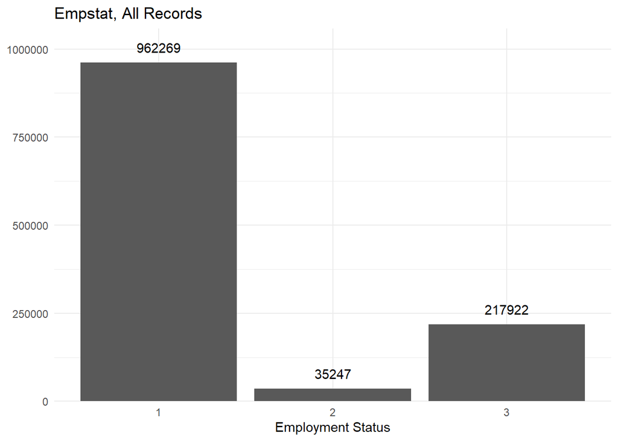

```r
acs_combined %>%
  count(empstat) %>%
  ggplot(mapping = aes(x = factor(empstat), y = n)) +
  geom_col() +
  geom_text(mapping = aes(label = n), vjust = -1) +
  scale_y_continuous(expand = expansion(mult = c(0, 0.1))) +
  labs(
    title = "Empstat, All Records",
    x = "Employment Status",
    y = NULL
  )
```

Turn the missing/“not in universe” value from the empstat variable into NAs. Rename to the more meaningful “employment_status”.

```r
acs_clean <- acs_combined %>%
  mutate(
    employment_status = ifelse(
      empstat == 0,
      NA_integer_,
      empstat)
  )
```

Look at distribution of `employment_status` after adjustment. There should be no more records with the value “0”.

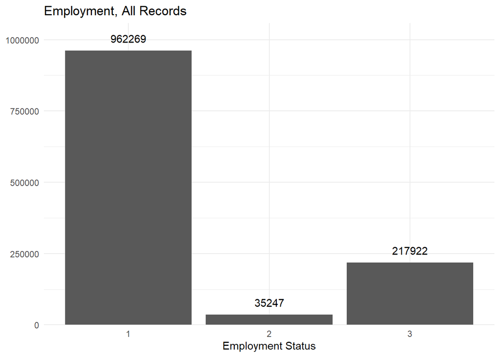

```r
acs_clean %>%
  count(employment_status) %>%
  ggplot(mapping = aes(x = factor(employment_status), y = n)) +
  geom_col() +
  geom_text(mapping = aes(label = n), vjust = -1) +
  scale_y_continuous(expand = expansion(mult = c(0, 0.1))) +
  labs(
    title = "Employment, All Records",
    x = "Employment Status",
    y = NULL
  )
```

Filter for group quarters (GQ), we want to keep only households including additional households under updated definitions.

```r
count(acs_clean, gq)
```

```
# A tibble: 5 x 2
  gq                                                n
  <fct>                                         <int>
1 Households under 1970 definition            1160638
2 Additional households under 1990 definition    2391
3 Group quarters--Institutions                  32808
4 Other group quarters                          19297
5 Additional households under 2000 definition     304
```

```r
acs_clean <- acs_clean %>%
  filter(gq %in% c("Households under 1970 definition",
                   "Additional households under 1990 definition",
                   "Additional households under 2000 definition"))
```

Check that group quarters fall only into household categories.

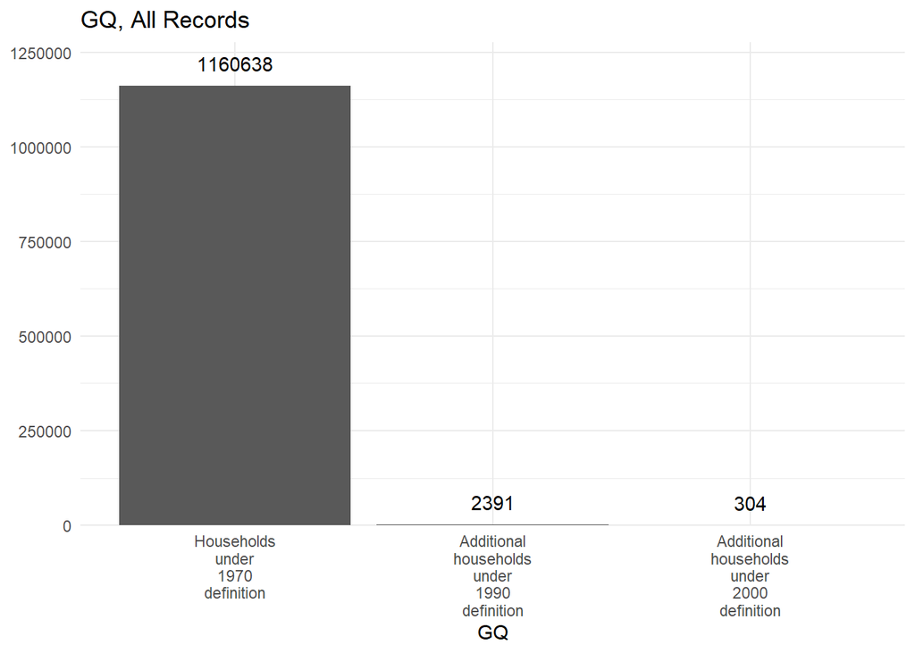

```r
acs_clean %>%
  count(gq) %>%
  ggplot(mapping = aes(x = gq, y = n)) +
  geom_col() +
  geom_text(mapping = aes(label = n), vjust = -1) +
  scale_y_continuous(expand = expansion(mult = c(0, 0.1))) +
  scale_x_discrete(labels = label_wrap(10)) +
  labs(
    title = "GQ, All Records",
    x = "GQ",
    y = NULL
  )
```

```r
rm(acs_combined)
```

## Crosswalk

Read in the PUMA to place crosswalk file. This file is created by the program generate_puma_place_crosswalks.rmd in the geographic-crosswalks folder.

```r
puma_place_crosswalk <- read_csv(
  here::here("geographic-crosswalks", "data", "crosswalk_puma_to_place.csv")
)
```

Create a version with just unique place for creating a version of the data that matches the UMF place list.

```r
place_list <- puma_place_crosswalk %>%
  select(statefip, place) %>%
  filter(statefip != 72) %>%
  unique()
```

## Merge Crosswalk

Create a variable in the ACS data indicating whether the survey is pre or post-2022. This will be used to join on the correct crosswalk information.

```r
acs_clean <- acs_clean %>%
  mutate(crosswalk_period = ifelse(year < 2022, "pre-2022", "2022"))
```

Check that the assignment worked. All years prior to 2022 should be designated “pre-2022”.

```r
count(acs_clean, crosswalk_period, year)
```

```
# A tibble: 1 x 3
  crosswalk_period  year       n
  <chr>            <int>   <int>
1 2022              2023 1163333
```

Join the cleaned ACS data onto the crosswalk.

```r
acs_crosswalked <- left_join(
  acs_clean,
  puma_place_crosswalk,
  by = c("crosswalk_period", "statefip","puma"),
  relationship = "many-to-many"
)

rm(acs_clean)
```

Check that each place has joined to many ACS records. We select the largest 486 places in our crosswalk, all 486 unique places should be connected to multiple records.

```r
acs_crosswalked %>%
  group_by(place, statefip) %>%
  count()
```

```
# A tibble: 536 x 3
# Groups:   place, statefip [536]
   place statefip     n
   <chr> <chr>    <int>
 1 00562 06         665
 2 00884 06         551
 3 01000 36         294
 4 01000 39        1644
 5 01000 48        1513
 6 01000 51         777
 7 01924 48        1639
 8 02000 06        5506
 9 02000 35        1877
10 02000 42         223
# i 526 more rows
```

Drop any observations with NA for `afact` (i.e. there is no place of interest overlapping this PUMA).

```r
count(acs_crosswalked, is.na(afact))
```

```
# A tibble: 2 x 2
  `is.na(afact)`      n
  <lgl>           <int>
1 FALSE          728412
2 TRUE           592673
```

```r
acs_crosswalked <- acs_crosswalked %>%
  drop_na(afact)
```

Also filter out cases where `afact` is equal to zero. These cases will not be counted in the metric calculation.

```r
count(acs_crosswalked, afact == 0)
```

```
# A tibble: 1 x 2
  `afact == 0`      n
  <lgl>         <int>
1 FALSE        728412
```

```r
acs_crosswalked <- acs_crosswalked %>%
  filter(afact > 0)
```

Adjust the person weight to account for PUMA-to-place mapping (those where the PUMA is not entirely inside the place).

```r
select(acs_crosswalked, perwt, repwtp1, repwtp80, afact)
```

```
# A tibble: 728,412 x 4
   perwt repwtp1 repwtp80  afact
   <dbl>   <dbl>    <dbl>  <dbl>
 1    90      27      137 0.0326
 2    64      19       99 0.0326
 3   148      35      134 0.595
 4   198      66       61 0.0139
 5   198      66       61 0.194
 6   190      54       62 0.0139
 7   190      54       62 0.194
 8    18       6       20 0.514
 9    34       9       30 0.514
10   171     269      194 0.514
# i 728,402 more rows
```

```r
acs_crosswalked <- acs_crosswalked %>%
  mutate(perwt = perwt * afact) %>%
  mutate(across(matches("repwtp[0-9]+"), ~.x * afact))

select(acs_crosswalked, perwt, repwtp1, repwtp80, afact)
```

```
# A tibble: 728,412 x 4
   perwt repwtp1 repwtp80  afact
   <dbl>   <dbl>    <dbl>  <dbl>
 1  2.93   0.880    4.47  0.0326
 2  2.09   0.619    3.23  0.0326
 3 88.1   20.8     79.8   0.595
 4  2.75   0.917    0.848 0.0139
 5 38.4   12.8     11.8   0.194
 6  2.64   0.751    0.862 0.0139
 7 36.8   10.5     12.0   0.194
 8  9.25   3.08    10.3   0.514
 9 17.5    4.62    15.4   0.514
10 87.9  138.      99.7   0.514
# i 728,402 more rows
```

## Prepare computational variables

Create a binary employed variable for calculating the share employed. IPUMS data codes “Employed” as equal to 1.

```r
acs_crosswalked <- acs_crosswalked %>%
  mutate(employed = employment_status == 1)
```

Check if `employment_status` is ever `NA`.

```r
stopifnot(sum(is.na(acs_crosswalked$employment_status)) == 0)
```

Confirm there are no vacant properties included in the data.

```r
stopifnot(sum(is.na(acs_crosswalked$vacancy)) == 0)
```

## Create employment metric: All

### Pre-drop suppressed cells

First, to save time when processing the metric, calculate the effective sample count for each place, defined as the sum of the `afact` variable. This is used to create a cutoff for data quality based on the actual number of survey records being used in the calculation. We will not include places with less than 30 effective samples.

```r
acs_all <- acs_crosswalked %>%
  group_by(year, sample, crosswalk_period, statefip, place) %>%
  mutate(effective_sample = sum(afact)) %>%
  ungroup()

# calculate the number of statistics after suppressing values
acs_all %>%
  group_by(year, sample, crosswalk_period, statefip, place) %>%
  summarize(
    effective_sample = max(effective_sample)
  ) %>%
  ungroup() %>%
  summarize(
    original_stats = n(),
    unsuppressed_stats = sum(effective_sample >= 30)
  )
```

```
# A tibble: 1 x 2
  original_stats unsuppressed_stats
           <int>              <int>
1            486                486
```

Create the employment metric.

Objective: get the percent of individuals between the ages 25 and 54 that are employed from the employment_status variable.

Aggregation should be weighted by PERWT (this is a person level statistic).

Remove records from places below the size quality cutoff.

```r
acs_all <- acs_all %>%
  filter(effective_sample >= 30)
```

### Calculate metric

Calculate the place-level metrics.

Calc_survey_mean takes the acs data and transitions it into a srvyr object. This allows the program to apply survey_mean which is a powerful function that calculates precise confidence intervals from datasets with replicate weights.

```r
results_all <- acs_all %>%
  group_split(statefip) %>%
  map_dfr(~ calc_survey_mean(.data = .x, .geo_level = place))
```

Clean up the confidence interval bounds and sort the data.

```r
results_all <- finalize_metric(results_all)
```

```r
rm(acs_all)
```

## Add Suppressed Rows to Data

To create the metric we suppressed places that did not meet the threshold for sample size but we need to include these in the final data. Create an all version of the data that includes places that were suppressed prior to the survey_mean calculation.

Expand the place_list file so it includes every year in the results. Join the results onto this file and test that the number of records matches the total number of places we anticipate.

```r
expanded_place_list <- place_list %>%
  left_join(results_all, by = c("statefip", "place"), relationship = "many-to-many") %>%
  mutate(geoid = paste0(statefip, place)) %>%
  expand(year, geoid) %>%
  mutate(statefip = str_sub(geoid, 1, 2),
         place = str_sub(geoid, 3, 7))

results_all_expand <- expanded_place_list %>%
  left_join(results_all, by = c("year", "statefip", "place")) %>%
  filter(!is.na(year))

stopifnot(nrow(results_all_expand) == 486 * n_distinct(results_all_expand$year))
```

## Data Quality Flags

Add a flag for data quality, this is a numeric variable between 1 and 3 with 1 representing the best quality and 3 representing the worst.

```r
metrics_employment_all <- results_all_expand %>%
  mutate(
    share_employed_quality = if_else(
      is.na(share_employed),
      NA_real_,
      geographic_allocation_quality
    )
  )
```

### Write out intermediate data

```r
if(isTRUE(bucket_exists(bucket = my_bucket))){
    # write file to S3
    tmp <- tempfile()
    on.exit(unlink(tmp))
    write_csv(metrics_employment_all, file = tmp)

    # put object with an upload progress bar
    put_object(tmp, object = paste0(s3_dir, "/metrics_employment_all", "_", params$year, ".csv"), bucket = my_bucket,
               show_progress = FALSE, multipart = FALSE)

  } else{
  #write file to temporary intermediate folder
  write_csv(paste0(here::here("09_employment", "data", "intermediate"),
                  "/", "metrics_employment_all_", params$year, ".csv"))
  }
```

```
[1] TRUE
```

If updating a single year the program ends here. To see validation results re-run with selection that all years of intermediate data are available.

```r
if(single_year_update == "Yes"){
  knitr::knit_exit()
}
```

## Validation

Validate results for all years of available output.

### Read intermediate files

Read in the intermediate files created for each ACS year available.

Function reads the CSVs from intermediate folder or from AWS if the user has access.

```r
read_intermediate <- function(year, file_type){

  if(isTRUE(bucket_exists(bucket = my_bucket))) {

    data_year <- s3read_using(FUN=read_csv,
                 bucket = my_bucket,
                 object=paste0(s3_dir, "/metrics_employment_", file_type, "_", year, ".csv")) %>%
      mutate(crosswalk_period = as.character(crosswalk_period))

  }
  else{

  read_csv(paste0(here::here("09_employment", "data", "intermediate"),
                  "/", "metrics_employment_", file_type, "_", year, ".csv"))
  }

}
```

```r
metrics_employment_all <- map_df(.x = existing_years, .f = ~read_intermediate(year = .x,
                                                                          file_type = "all"))
```

Tabulate count of results by year.

```r
metrics_employment_all %>%
  group_by(year) %>%
  count()
```

```
# A tibble: 9 x 2
# Groups:   year [9]
   year     n
  <dbl> <int>
1  2014   486
2  2015   486
3  2016   486
4  2017   486
5  2018   486
6  2019   486
7  2021   486
8  2022   486
9  2023   486
```

Show summary statistics for the metric across all places in the 1-year data.

```r
metrics_employment_all %>%
  select(share_employed:share_employed_quality) %>%
  summary()
```

```
 share_employed   geographic_allocation_quality share_employed_lb
 Min.   :0.4918   Min.   :1.000                 Min.   :0.4057
 1st Qu.:0.7693   1st Qu.:1.000                 1st Qu.:0.7280
 Median :0.8027   Median :2.000                 Median :0.7660
 Mean   :0.7970   Mean   :1.932                 Mean   :0.7594
 3rd Qu.:0.8302   3rd Qu.:2.000                 3rd Qu.:0.7972
 Max.   :0.9333   Max.   :3.000                 Max.   :0.9104
 NA's   :7        NA's   :7                     NA's   :7
 share_employed_ub share_employed_quality
 Min.   :0.5779    Min.   :1.000
 1st Qu.:0.8084    1st Qu.:1.000
 Median :0.8397    Median :2.000
 Mean   :0.8347    Mean   :1.932
 3rd Qu.:0.8652    3rd Qu.:2.000
 Max.   :0.9704    Max.   :3.000
 NA's   :7         NA's   :7
```

Calculate the coefficient of variation for each year for the `share_employed` variable. The higher this number the greater variability in the data. Create a table descending by CV to see places with the largest variability.

```r
metrics_employment_all %>%
  group_by(year, place) %>%
  summarise(sd_employ = round(sd(share_employed, na.rm = TRUE), 3),
         mean_employ = round(mean(share_employed, na.rm = TRUE), 3),
         cv = round(sd_employ/mean_employ, 3)) %>%
  arrange(desc(cv)) %>%
  reactable()
```

| year | place | sd_employ | mean_employ | cv |
| --- | --- | --- | --- | --- |
| 2021 | 22000 | 0.202 | 0.729 | 0.277 |
| 2016 | 29000 | 0.171 | 0.69 | 0.248 |
| 2015 | 22000 | 0.17 | 0.693 | 0.245 |
| 2022 | 22000 | 0.166 | 0.723 | 0.23 |
| 2017 | 29000 | 0.162 | 0.707 | 0.229 |
| 2023 | 31000 | 0.16 | 0.732 | 0.219 |
| 2019 | 29000 | 0.143 | 0.719 | 0.199 |
| 2014 | 29000 | 0.136 | 0.696 | 0.195 |
| 2014 | 22000 | 0.129 | 0.674 | 0.191 |
| 2016 | 22000 | 0.133 | 0.715 | 0.186 |

[output cut: 3464 more lines]

Look at distribution of `share_employed` for all places. We generally see a normal distribution.

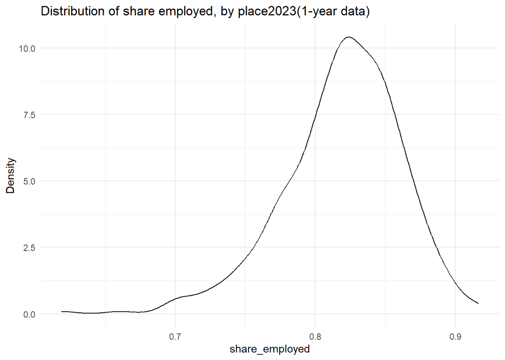

```r
metrics_employment_all %>%
  filter(year == params$year) %>%
  select(share_employed) %>%
  ggplot(aes(x = share_employed)) +
  geom_density(alpha = 0.15) +
  theme_minimal() +
  ggtitle(paste0("Distribution of share employed, by place", params$year, "(1-year data)")) +
  ylab("Density")
```

Look at the counts of the quality flag. For the 1-year data at the place level there are still a fair amount of quality “3” observations that we would suggest users disregard or use with caution.

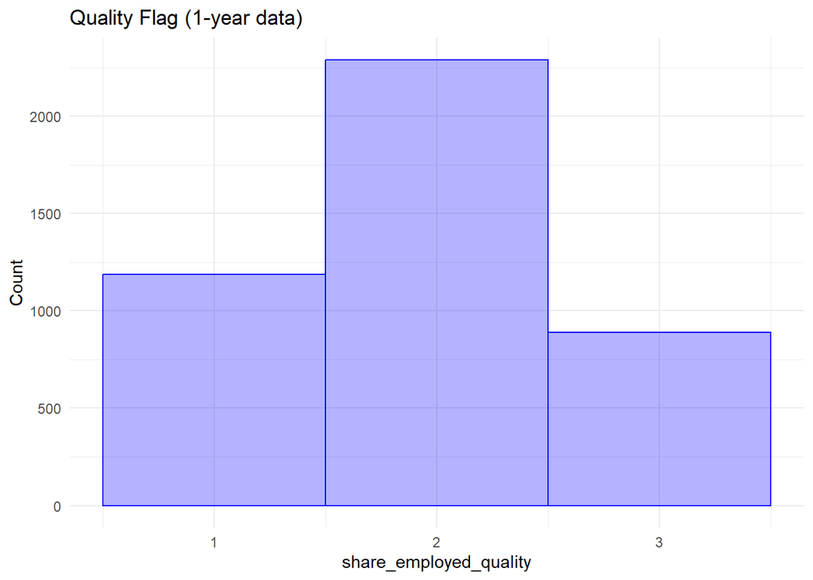

```r
metrics_employment_all %>%
  select(share_employed_quality) %>%
  ggplot(aes(x = share_employed_quality)) +
  geom_histogram(color = "blue", fill = alpha("blue", 0.3), binwidth = 1.0) +
  theme_minimal() +
  ggtitle("Quality Flag (1-year data)") +
  ylab("Count")
```

Tabulate share of data suppressed by year.

```r
metrics_employment_all %>%
  group_by(year) %>%
  filter(is.na(share_employed)) %>%
  count()
```

```
# A tibble: 7 x 2
# Groups:   year [7]
   year     n
  <dbl> <int>
1  2014     1
2  2015     1
3  2016     1
4  2017     1
5  2018     1
6  2019     1
7  2021     1
```

## Final Test and Export

Rename state.

```r
metrics_employment_all <- metrics_employment_all %>%
  rename("state" = "statefip")
```

Order the variables how we want.

```r
metrics_employment_all <- metrics_employment_all %>%
  select(year, state, place, share_employed, share_employed_lb,
         share_employed_ub, share_employed_quality)
```

Run file through evaluate final data function.

```r
evaluate_final_data(data = metrics_employment_all, exp_form_path = here::here("10a_final-evaluation", "evaluation_form_employment_overall_place.csv"), geography = "place", subgroups = FALSE, confidence_intervals = TRUE)
```

```
[1] "This data passes all tests!"
```

### Export as CSV.

```r
write_csv(metrics_employment_all, here::here("09_employment", "data", "final", "metrics_employment_place_all_longitudinal.csv"))
```